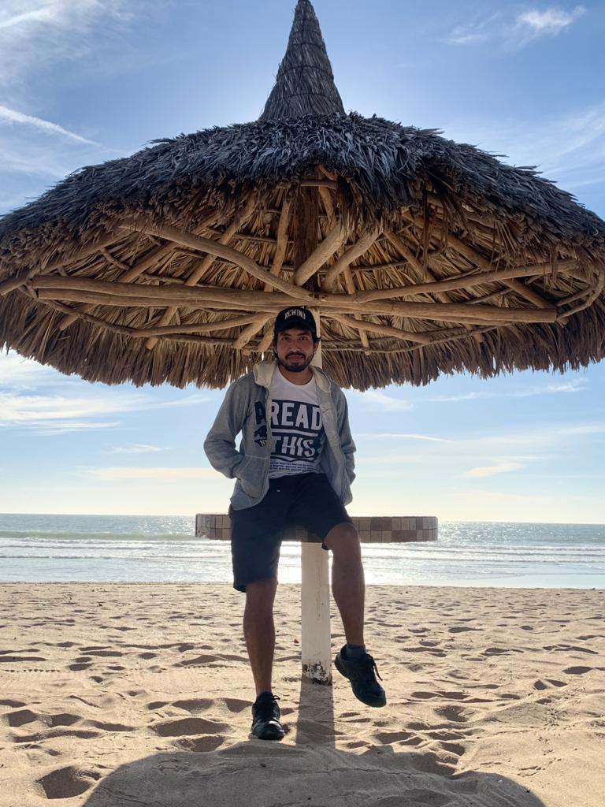

# Victor Hugo Caña Bozada

### About

#### Experience

Investigator  
Central Research Department of Universidad Laica Eloy Alfaro de Manabí (ULEAM), Manta, Ecuador  
January 2015 - December 2015  
Project: “Biodiversity and community structure of metazoan parasites in economically important marine fish in Ecuador”

Research Assistant Student in Investigator  
Central Research Department of Universidad Laica Eloy Alfaro de Manabí (ULEAM), Manta, Ecuador  
March 2013 - December 2014  
Project: “Occurrence of parasitic copepods in economically important marine fish in Ecuador”

#### Education

PhD student, Doctor of Science  
Research Center for Food and Development A.C. Mazatlán, México  
January 2020 - January 2024  
Field of study  
Aquaculture

Master of Science  
Research Center for Food and Development A.C. Mazatlán, México  
September 2017 - August 2019  
Field of study  
Aquaculture

Bachelor’s degree  
Universidad Laica Eloy Alfaro de Manabí (ULEAM). Manta, Ecuador  
April 2009 - July 2014  
Field of study  
Fishery biologist

#### Publications

Morales-Serna, F. N., Avalos-Soriano, A., Martínez-Brown, J. M., Caña-Bozada, López-Moreno, D.G., Mirabent-Casals M., & Fajer-Ávila, E. J. 2021. Parásitos de la clase Monogenea: un peligro para la producción de robalo. Industria Acuícola, 17, 5.

Caña-Bozada, V., Chapa-López, M., Díaz-Martín, R. D., García-Gasca, A., Huerta-Ocampo, J. Á., de Anda-Jáuregui, G., & Morales-Serna, F. N. 2021. In silico identification of excretory/secretory proteins and drug targets in monogenean parasites. Infection, Genetics and Evolution, 93, 104931.

Caña-Bozada, V., Llera-Herrera, R., Fajer-Ávila, E. J., & Morales-Serna, F. N. 2021. Mitochondrial genome of Rhabdosynochus viridisi (Monogenea: Diplectanidae), a parasite of Pacific white snook Centropomus viridis. Journal of Helminthology, 95.

Caña-Bozada, V., Llera-Herrera, R., Morales-Serna, F.N., Fajer-Ávila, E.J. 2021. Mitochondrial genome of Scutogyrus longicornis (Monogenea: Dactylogyridea), a parasite of Nile tilapia Oreochromis niloticus. Parasitology International, 81, 102281.

Caña-Bozada, V., Morales-Serna, F.N., García-Gasca, A., Llera-Herrera, R., & Fajer-Ávila, E.J. 2019. Genome-wide identification of ABC transporters in monogeneans. Molecular and biochemical parasitology, 234, 111234.

Morales-Serna, F.N., Caña-Bozada, V., López-Moreno, D.G., Medina-Guerrero, R.M., Morales-Serna, J.A., Fajer-Ávila, E.J. 2019. In vitro efficacy of two terpenes against ancyrocephalid monogeneans from Nile tilapia. Journal of Parasitic Diseases. Journal of Parasitic Diseases, 43(4), 739-742.

Cruz-Quintana, Y., Caña-Bozada, V., Suárez-Morales, E., Santana-Piñeros, A. M. 2018. A new species of Pupulina van Beneden, 1892 (Copepoda, Siphonostomatoida, Caligidae) from Aetobatuscf. narinari (Pisces, Myliobatidae) from the Pacific coast of Ecuador. ZooKeys (777), 1.

Morales-Serna, F.N., Caña-Bozada, V., Mera-Loor, G., Loor-Andrade, P., Fajer-Ávila, E.J., Ho, J.S. 2015. New records of sea lice (Copepoda: Caligidae) from marine fishes in Jaramijó, an area with potential for sea-cage aquaculture in Ecuador. Zootaxa (2): 366–380.

### Conference Paper

Santana-Piñeros, A.M., Caña-Bozada, V., Mera-Loor, G., Loor-Andrade, P. y Morales-Serna, F.N. 2015. Diversidad de copépodos parásitos en peces marinos de Ecuador. Foro Iberoamericano de los Recursos Marinos y la Acuicultura VII: 31-41.

Morales-Serna, F.N., Loor-Andrade, P., Caña-Bozada, V., Mera-Loor, G., Fajer-Ávila, E.J. 2014. Occurrence of sea lice (Copepoda: Caligidae) on marine fishes from Jaramijo, an area with potential for sea-cage aquaculture in Ecuador. Memorias del congreso The 10th International Sea Lice Conference. Portland, Maine, EEUU, 2014. 103p.

### Contact

victorcana1991@hotmail.com